# Barbell Lift Prediction Analysis

Villads J

## Introduction

This report aims to predict the manner in which participants performed barbell lifts using data collected from accelerometers. The “classe” variable in the training set represents the manner of execution and is the target variable for this analysis.

## Data Loading and Preprocessing

First the training and test data is loaded.

```r
# Load required libraries
library(caret)
library(dplyr)
```

```r
library(ggplot2)

# Load data
training_url <- "https://d396qusza40orc.cloudfront.net/predmachlearn/pml-training.csv"
test_url <- "https://d396qusza40orc.cloudfront.net/predmachlearn/pml-testing.csv"

training_data <- read.csv(training_url, na.strings = c("NA", "", "#DIV/0!"))
testing_data <- read.csv(test_url, na.strings = c("NA", "", "#DIV/0!"))

# Inspect data structure
str(training_data)
```

```
## 'data.frame':    19622 obs. of  160 variables:
##  $ X                       : int  1 2 3 4 5 6 7 8 9 10 ...
##  $ user_name               : chr  "carlitos" "carlitos" "carlitos" "carlitos" ...
##  $ raw_timestamp_part_1    : int  1323084231 1323084231 1323084231 1323084232 1323084232 1323084232 1323084232 1323084232 1323084232 1323084232 ...
##  $ raw_timestamp_part_2    : int  788290 808298 820366 120339 196328 304277 368296 440390 484323 484434 ...
##  $ cvtd_timestamp          : chr  "05/12/2011 11:23" "05/12/2011 11:23" "05/12/2011 11:23" "05/12/2011 11:23" ...
##  $ new_window              : chr  "no" "no" "no" "no" ...
##  $ num_window              : int  11 11 11 12 12 12 12 12 12 12 ...
##  $ roll_belt               : num  1.41 1.41 1.42 1.48 1.48 1.45 1.42 1.42 1.43 1.45 ...
##  $ pitch_belt              : num  8.07 8.07 8.07 8.05 8.07 8.06 8.09 8.13 8.16 8.17 ...
##  $ yaw_belt                : num  -94.4 -94.4 -94.4 -94.4 -94.4 -94.4 -94.4 -94.4 -94.4 -94.4 ...
##  $ total_accel_belt        : int  3 3 3 3 3 3 3 3 3 3 ...
##  $ kurtosis_roll_belt      : num  NA NA NA NA NA NA NA NA NA NA ...
##  $ kurtosis_picth_belt     : num  NA NA NA NA NA NA NA NA NA NA ...
##  $ kurtosis_yaw_belt       : logi  NA NA NA NA NA NA ...
```

[output cut: 86 more lines]

### Data Cleaning

From inspecting the data, we see a lot of Na values and index coulmns with no predictive value. So we remove coulmns with more than 95 % missing values, Remove coulmns with near zero variance, and ensure class is a factor.

```r
nzv <- nearZeroVar(training_data)
training_data <- training_data[, -nzv]

missing_data <- sapply(training_data, function(x) mean(is.na(x)))
training_data <- training_data[, missing_data < 0.95]

training_data <- training_data[, -(1:5)]

training_data$classe <- as.factor(training_data$classe)
```

## Exploratory Data Analysis

Now we produce a summery of the cleaned data and try to plot of the variable in a pairwise scatterplots of multiple variables in a grid format, which is useful for visually exploring relationships between variables.

```r
# Distribution of the target variable
summary(training_data$classe)
```

```
##    A    B    C    D    E
## 5580 3797 3422 3216 3607
```

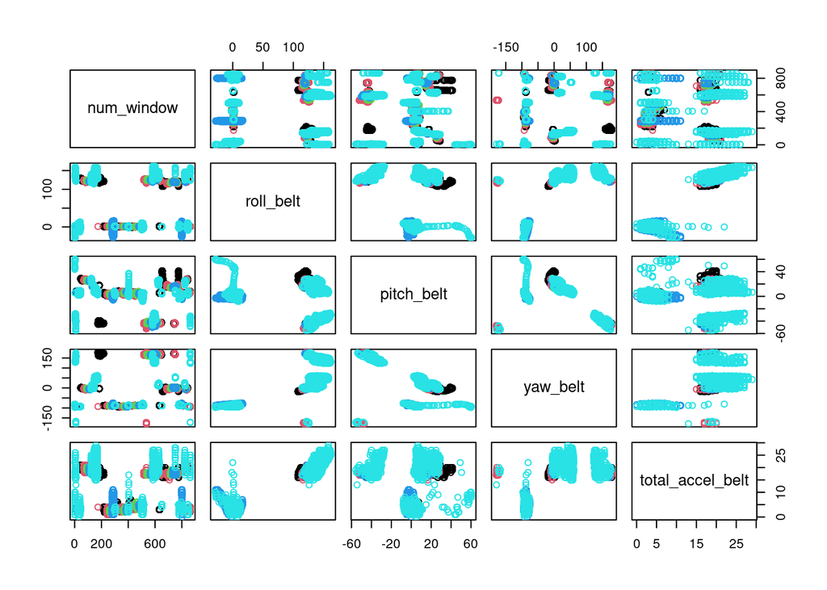

```r
numeric_columns <- sapply(training_data, is.numeric)
numeric_training_data <- training_data[, numeric_columns]

# Use only the first 5 numeric columns for the pairs plot
pairs(numeric_training_data[, 1:5], col = training_data$classe)
```

## Model Building

### Data Splitting

We split the training data into a training and validation test to reduce the risk of overfitting.

```r
set.seed(1234)
training_index <- createDataPartition(training_data$classe, p = 0.7, list = FALSE)
training_set <- training_data[training_index, ]
validation_set <- training_data[-training_index, ]
```

### Model Selection

We use the randomoforrest model with 5-fold cross validation. The sample size is reduced to 5000 samples to reduce the training time.

```r
# Train a Random Forest model
set.seed(1234)
training_sample <- training_set[sample(nrow(training_set), size = 5000), ]  # Reduce to 5,000 rows
model_rf <- train(
  classe ~ .,
  data = training_sample,
  method = "rf",
  trControl = trainControl(method = "cv", number = 5),
  importance = TRUE
)

print(model_rf)
```

```
## Random Forest
##
## 5000 samples
##   53 predictor
##    5 classes: 'A', 'B', 'C', 'D', 'E'
##
## No pre-processing
## Resampling: Cross-Validated (5 fold)
## Summary of sample sizes: 4000, 3999, 4000, 3999, 4002
## Resampling results across tuning parameters:
##
##   mtry  Accuracy   Kappa
##    2    0.9750006  0.9682942
##   27    0.9848016  0.9807342
##   53    0.9807996  0.9756603
##
## Accuracy was used to select the optimal model using the largest value.
## The final value used for the model was mtry = 27.
```

## Model Evaluation

We now plot the confusion matrix of the prediction from out validation set.

```r
# Predict on validation set
predictions <- predict(model_rf, validation_set)
confusion_matrix <- confusionMatrix(predictions, validation_set$classe)

print(confusion_matrix)
```

```
## Confusion Matrix and Statistics
##
##           Reference
## Prediction    A    B    C    D    E
##          A 1674   13    0    0    0
##          B    0 1106   32    0    2
##          C    0   19  993   10    0
##          D    0    1    1  952    2
##          E    0    0    0    2 1078
##
## Overall Statistics
##
##                Accuracy : 0.9861
##                  95% CI : (0.9827, 0.9889)
##     No Information Rate : 0.2845
##     P-Value [Acc > NIR] : < 2.2e-16
##
##                   Kappa : 0.9824
##
##  Mcnemar's Test P-Value : NA
##
## Statistics by Class:
##
##                      Class: A Class: B Class: C Class: D Class: E
## Sensitivity            1.0000   0.9710   0.9678   0.9876   0.9963
## Specificity            0.9969   0.9928   0.9940   0.9992   0.9996
## Pos Pred Value         0.9923   0.9702   0.9716   0.9958   0.9981
## Neg Pred Value         1.0000   0.9930   0.9932   0.9976   0.9992
## Prevalence             0.2845   0.1935   0.1743   0.1638   0.1839
## Detection Rate         0.2845   0.1879   0.1687   0.1618   0.1832
## Detection Prevalence   0.2867   0.1937   0.1737   0.1624   0.1835
## Balanced Accuracy      0.9985   0.9819   0.9809   0.9934   0.9979
```

## Predicting Test Cases

```r
# Predict on test set
test_predictions <- predict(model_rf, testing_data)

# Display predictions
test_predictions
```

```
##  [1] B A B A A E D B A A B C B A E E A B B B
## Levels: A B C D E
```

## Conclusion

This analysis demonstrated the use of Random Forest to predict barbell lift execution. The model was evaluated using cross-validation and showed strong performance on the validation set.